# Global COVID-19 Data

2022-08-16

## The Data

We begin by getting and tidying the data.

```r
library(tidyverse)
library(lubridate)
library(dplyr)
library(ggplot2)

url_in <- "https://raw.githubusercontent.com/CSSEGISandData/COVID-19/master/csse_covid_19_data/csse_covid_19_time_series/"

file_names <- c("time_series_covid19_confirmed_global.csv", "time_series_covid19_deaths_global.csv")

urls <- str_c(url_in, file_names)
global_cases <- read_csv(urls[1])
global_deaths <- read_csv(urls[2])

global_cases <- global_cases %>%
  pivot_longer(cols = -c('Province/State', 'Country/Region', Lat, Long), names_to = "date", values_to = "cases") %>%
  select(-c(Lat,Long))

global_deaths <- global_deaths %>%
  pivot_longer(cols = -c('Province/State', 'Country/Region', Lat, Long), names_to = "date", values_to = "deaths") %>%
  select(-c(Lat,Long))

global <- global_cases %>% full_join(global_deaths) %>%
  rename(Country_Region = 'Country/Region',
         Province_State = 'Province/State') %>%
  mutate(date = mdy(date))

global <- global %>% filter(cases > 0)

global <- global %>%
  unite("Combined_Key", c(Province_State, Country_Region),
        sep = ", ",
        na.rm = TRUE,
        remove = FALSE)

uid_lookup_url <- "https://raw.githubusercontent.com/CSSEGISandData/COVID-19/master/csse_covid_19_data/UID_ISO_FIPS_LookUp_Table.csv"

uid <- read_csv(uid_lookup_url) %>% select(-c(Lat, Long_, Combined_Key, code3, iso2, iso3, Admin2))

global <- global %>%
  left_join(uid, by = c("Province_State", "Country_Region")) %>% select(-c(UID, FIPS)) %>% select(Province_State, Country_Region, date, cases, deaths, Population, Combined_Key)

global
```

```
## # A tibble: 247,017 × 7
##    Province_State Country_Region date       cases deaths Population Combined_Key
##    <chr>          <chr>          <date>     <dbl>  <dbl>      <dbl> <chr>
##  1 <NA>           Afghanistan    2020-02-24     5      0   38928341 Afghanistan
##  2 <NA>           Afghanistan    2020-02-25     5      0   38928341 Afghanistan
##  3 <NA>           Afghanistan    2020-02-26     5      0   38928341 Afghanistan
##  4 <NA>           Afghanistan    2020-02-27     5      0   38928341 Afghanistan
##  5 <NA>           Afghanistan    2020-02-28     5      0   38928341 Afghanistan
##  6 <NA>           Afghanistan    2020-02-29     5      0   38928341 Afghanistan
##  7 <NA>           Afghanistan    2020-03-01     5      0   38928341 Afghanistan
##  8 <NA>           Afghanistan    2020-03-02     5      0   38928341 Afghanistan
##  9 <NA>           Afghanistan    2020-03-03     5      0   38928341 Afghanistan
## 10 <NA>           Afghanistan    2020-03-04     5      0   38928341 Afghanistan
## # … with 247,007 more rows
## # ℹ Use `print(n = ...)` to see more rows
```

```r
summary(global)
```

```
##  Province_State     Country_Region          date                cases
##  Length:247017      Length:247017      Min.   :2020-01-22   Min.   :       1
##  Class :character   Class :character   1st Qu.:2020-10-18   1st Qu.:     874
##  Mode  :character   Mode  :character   Median :2021-05-31   Median :   13189
##                                        Mean   :2021-05-28   Mean   :  745135
##                                        3rd Qu.:2022-01-08   3rd Qu.:  192171
##                                        Max.   :2022-08-14   Max.   :92927104
##
##      deaths          Population        Combined_Key
##  Min.   :      0   Min.   :8.090e+02   Length:247017
##  1st Qu.:      6   1st Qu.:7.892e+05   Class :character
##  Median :    155   Median :7.133e+06   Mode  :character
##  Mean   :  12232   Mean   :2.921e+07
##  3rd Qu.:   2837   3rd Qu.:2.914e+07
##  Max.   :1037021   Max.   :1.380e+09
##                    NA's   :5073
```

Above we can see a snapshot of the data for some countries as well as a summary of all the data.

```r
global_by_country <- global %>% group_by(Province_State, Country_Region, date) %>% summarize(cases = sum(cases), deaths = sum(deaths), Population = sum(Population)) %>% mutate(deaths_per_mill = deaths *1000000 / Population) %>% select(Province_State, Country_Region, date, cases, deaths, deaths_per_mill, Population) %>% ungroup()
global_by_country
```

```
## # A tibble: 247,017 × 7
##    Province_State Country_Region date       cases deaths deaths_per_mill Popul…¹
##    <chr>          <chr>          <date>     <dbl>  <dbl>           <dbl>   <dbl>
##  1 Alberta        Canada         2020-03-06     1      0               0 4442879
##  2 Alberta        Canada         2020-03-07     2      0               0 4442879
##  3 Alberta        Canada         2020-03-08     4      0               0 4442879
##  4 Alberta        Canada         2020-03-09     7      0               0 4442879
##  5 Alberta        Canada         2020-03-10     7      0               0 4442879
##  6 Alberta        Canada         2020-03-11    19      0               0 4442879
##  7 Alberta        Canada         2020-03-12    19      0               0 4442879
##  8 Alberta        Canada         2020-03-13    29      0               0 4442879
##  9 Alberta        Canada         2020-03-14    29      0               0 4442879
## 10 Alberta        Canada         2020-03-15    39      0               0 4442879
## # … with 247,007 more rows, and abbreviated variable name ¹Population
## # ℹ Use `print(n = ...)` to see more rows
```

Here we’ve rearranged the data so that it’s organized by country.

```r
global_country_totals <- global_by_country %>%
  group_by(Country_Region) %>%
  summarize(deaths = max(deaths), cases = max(cases), population = max(Population), cases_per_thou = 1000*cases / population, deaths_per_thou = 1000*deaths / population) %>% filter(cases>0, population>0)

global_country_totals %>% slice_min(deaths_per_thou, n = 10)
```

```
## # A tibble: 10 × 6
##    Country_Region deaths  cases population cases_per_thou deaths_per_thou
##    <chr>           <dbl>  <dbl>      <dbl>          <dbl>           <dbl>
##  1 Holy See            0     29        809     35.8              0
##  2 Korea, North        6      1   25778815      0.0000388        0.000233
##  3 Burundi            38  48002   11890781      4.04             0.00320
##  4 Chad              193   7444   16425859      0.453            0.0117
##  5 South Sudan       138  17823   11193729      1.59             0.0123
##  6 Niger             311   9132   24206636      0.377            0.0128
##  7 Tajikistan        125  17786    9537642      1.86             0.0131
##  8 Benin             163  27316   12123198      2.25             0.0134
##  9 Tanzania          841  38205   59734213      0.640            0.0141
## 10 Nigeria          3148 262520  206139587      1.27             0.0153
```

Above you can see the countries that have the fewest deaths per thousand.

```r
global_country_totals %>% slice_max(deaths_per_thou, n = 10)
```

```
## # A tibble: 10 × 6
##    Country_Region         deaths   cases population cases_per_thou deaths_per_…¹
##    <chr>                   <dbl>   <dbl>      <dbl>          <dbl>         <dbl>
##  1 Peru                   214956 4027614   32971846           122.          6.52
##  2 Bulgaria                37488 1226419    6948445           177.          5.40
##  3 Hungary                 46966 2005399    9660350           208.          4.86
##  4 Bosnia and Herzegovina  15942  390650    3280815           119.          4.86
##  5 North Macedonia          9414  334562    2083380           161.          4.52
##  6 Montenegro               2759  269719     628062           429.          4.39
##  7 Georgia                 16877 1710749    3989175           429.          4.23
##  8 Croatia                 16496 1200742    4105268           292.          4.02
##  9 Czechia                 40647 4012244   10708982           375.          3.80
## 10 Slovakia                20236 2584276    5434712           476.          3.72
## # … with abbreviated variable name ¹deaths_per_thou
```

And here you can see the countries that have the most deaths per thousand.

## Visualization

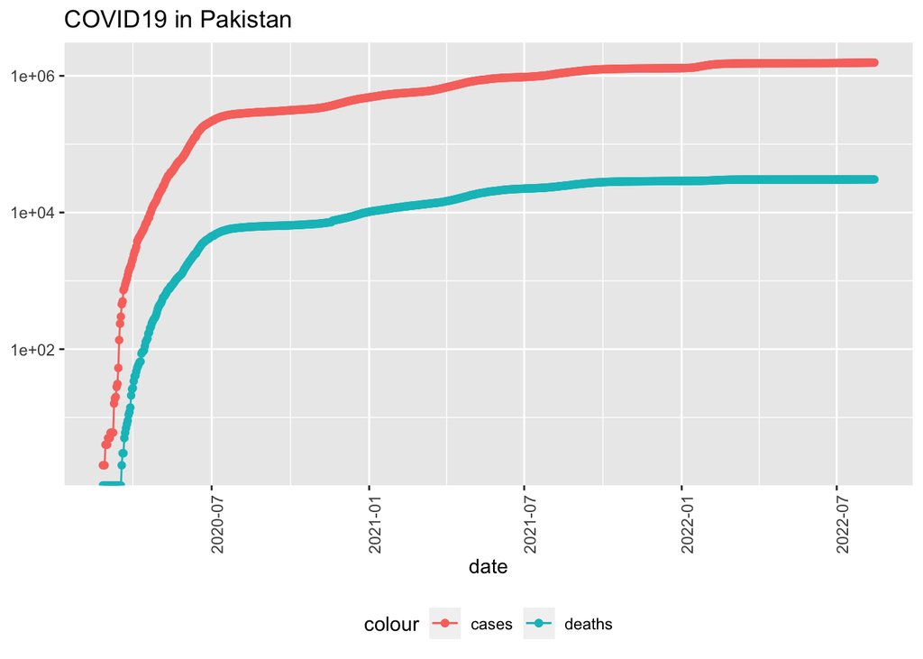

```r
country <- "Pakistan"
global_by_country %>% filter(Country_Region == country) %>% filter(cases > 0) %>% ggplot(aes(x=date, y=cases)) + geom_line(aes(color="cases")) + geom_point(aes(color ="cases")) + geom_line(aes(y= deaths, color="deaths")) + geom_point(aes(y=deaths, color="deaths")) + scale_y_log10() + theme(legend.position="bottom", axis.text.x = element_text(angle = 90)) + labs(title = str_c("COVID19 in ", country), y=NULL)
```

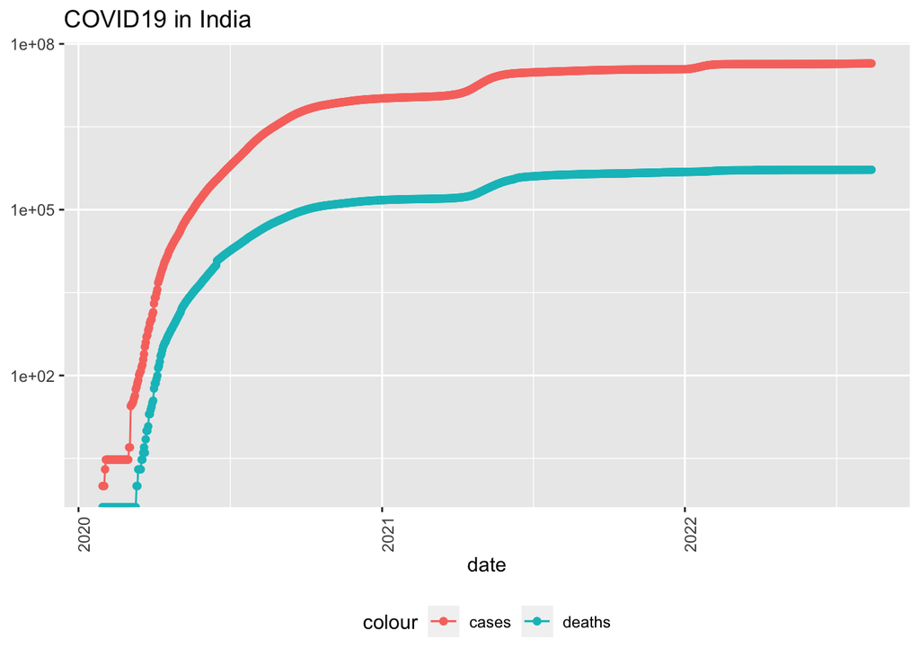

```r
country <- "India"
global_by_country %>% filter(Country_Region == country) %>% filter(cases > 0) %>% ggplot(aes(x=date, y=cases)) + geom_line(aes(color="cases")) + geom_point(aes(color ="cases")) + geom_line(aes(y= deaths, color="deaths")) + geom_point(aes(y=deaths, color="deaths")) + scale_y_log10() + theme(legend.position="bottom", axis.text.x = element_text(angle = 90)) + labs(title = str_c("COVID19 in ", country), y=NULL)
```

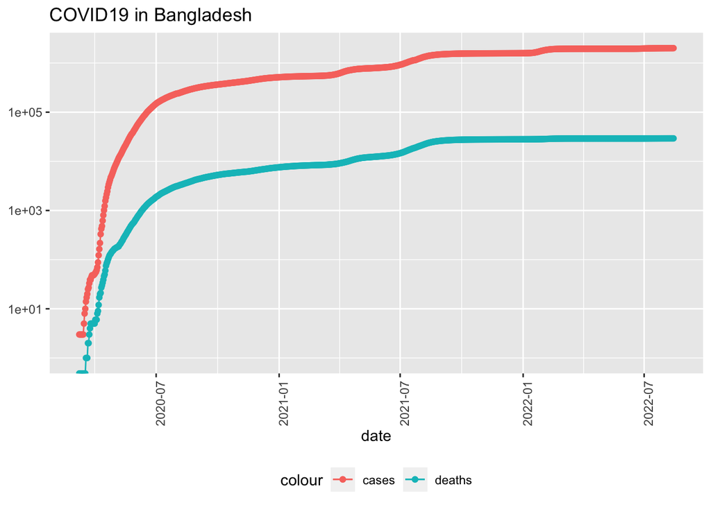

```r
country <- "Bangladesh"
global_by_country %>% filter(Country_Region == country) %>% filter(cases > 0) %>% ggplot(aes(x=date, y=cases)) + geom_line(aes(color="cases")) + geom_point(aes(color ="cases")) + geom_line(aes(y= deaths, color="deaths")) + geom_point(aes(y=deaths, color="deaths")) + scale_y_log10() + theme(legend.position="bottom", axis.text.x = element_text(angle = 90)) + labs(title = str_c("COVID19 in ", country), y=NULL)
```

Above, we can see the cases and deaths for 3 South Asian countries. There are some similarities between the three, but it can also be seen that each of their responses to the pandemic occurred at different times.

## Modeling

```r
mod <- lm(deaths_per_thou ~ cases_per_thou, data = global_country_totals)

summary(mod)
```

```
##
## Call:
## lm(formula = deaths_per_thou ~ cases_per_thou, data = global_country_totals)
##
## Residuals:
##     Min      1Q  Median      3Q     Max
## -2.4768 -0.5619 -0.4014  0.4261  5.4459
##
## Coefficients:
##                 Estimate Std. Error t value Pr(>|t|)
## (Intercept)    0.5768994  0.1068865   5.397  2.0e-07 ***
## cases_per_thou 0.0040651  0.0004763   8.536  4.4e-15 ***
## ---
## Signif. codes:  0 '***' 0.001 '**' 0.01 '*' 0.05 '.' 0.1 ' ' 1
##
## Residual standard error: 1.098 on 190 degrees of freedom
## Multiple R-squared:  0.2772, Adjusted R-squared:  0.2734
## F-statistic: 72.86 on 1 and 190 DF,  p-value: 4.397e-15
```

Above is the equation for the linear model of deaths per thousand as compared to cases per thousand.

```r
global_total_w_pred <- global_country_totals %>% mutate(pred = predict(mod))

global_total_w_pred
```

```
## # A tibble: 192 × 7
##    Country_Region      deaths   cases population cases_per_thou deaths_p…¹  pred
##    <chr>                <dbl>   <dbl>      <dbl>          <dbl>      <dbl> <dbl>
##  1 Afghanistan           7758  189045   38928341           4.86     0.199  0.597
##  2 Albania               3571  321804    2877800         112.       1.24   1.03
##  3 Algeria               6878  269141   43851043           6.14     0.157  0.602
##  4 Andorra                155   45899      77265         594.       2.01   2.99
##  5 Angola                1917  102636   32866268           3.12     0.0583 0.590
##  6 Antigua and Barbuda    144    8820      97928          90.1      1.47   0.943
##  7 Argentina           129566 9633732   45195777         213.       2.87   1.44
##  8 Armenia               8637  428648    2963234         145.       2.91   1.16
##  9 Australia             4955 3342373    8118000         412.       0.610  2.25
## 10 Austria              20485 4861952    9006400         540.       2.27   2.77
## # … with 182 more rows, and abbreviated variable name ¹deaths_per_thou
## # ℹ Use `print(n = ...)` to see more rows
```

Then we can see the predicted values next to the actual values.

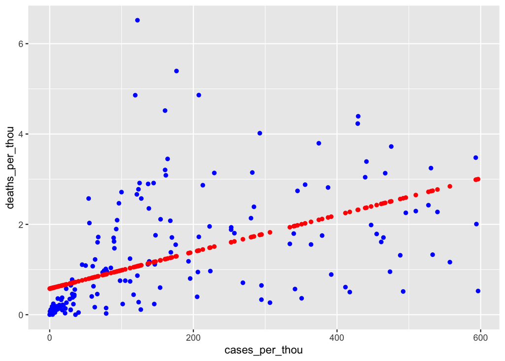

```r
global_total_w_pred %>% ggplot() + geom_point(aes(x=cases_per_thou, y=deaths_per_thou), color="blue") + geom_point(aes(x=cases_per_thou, y = pred), color="red")
```

Finally, we can see how our linear model compares to the actual data. The model is able to correctly predict that there are generally more deaths per thousand the more cases there are, but we can also see that there are many countries with very large residuals. Some countries have much more deaths per thousand despite not having as many cases as others. Also, the model over-predicts the deaths per thousand for a large cluster of countries in the bottom-left corner.

## Conclusion and Biases

From all this we can see that the cases per thousand people has an important effect on the number of deaths, but it is also clear that there are more factors at play. It is likely that the state of hospitals and number of doctors/nurses is extremely important for determining how many deaths occur. It is also possible that the cases are underreported due to many people being stuck at home, or being asymptomatic.

These other factors that are not included in this dataset are good to keep in mind in order to avoid prescribing the issue as simply having to do with the number of cases.